# Assignment 10B Nobel Prize

Author

Khandker Qaiduzzaman

# Objective

The goal of this assignment is to use the Nobel Prize API to retrieve JSON data, transform it into tidy data frames in R, and explore the dataset to answer four data-driven questions.

# Approach

This analysis focuses on retrieving structured JSON data from the Nobel Prize API, transforming it into tidy data using `tidyverse` principles, and preparing it for exploratory data analysis.

## Step 1: Data Collection Using Nobel Prize API

The dataset is obtained from the [Nobel Prize Developer Zone](https://www.nobelprize.org/organization/developer-zone-2/), which provides structured JSON data on Nobel laureates and prize awards.

Two endpoints are used:

- **Laureates Endpoint:** contains personal information such as name, gender, birth date, and country of birth
- **Prizes Endpoint:** contains award-level information such as year, category, and prize details

The data is retrieved in JSON format and converted into R data frames for further processing.

## Step 2: JSON Structure and Data Preparation

The JSON data is parsed using the `jsonlite` package with `flatten = TRUE` to partially simplify nested structures.

However, the datasets still contain complex nested components such as: - List-columns (e.g., `nobelPrizes`, `laureates`, `links`) - Nested identifiers inside sub-structures - Hierarchical fields generated from JSON paths (e.g., `birth.place.country.en`)

Initial inspection using `head()` and `glimpse()` is used to understand:

- Variable structure  
- Key identifiers (especially `id`)  
- Fields required for analysis (country, year, category)

Further data wrangling such as unnesting and restructuring will be required in later stages before analysis.

## Data Analysis Workflow

The workflow begins by retrieving JSON data from the Nobel Prize API and converting it into data frames.

Next, both datasets are explored to understand their structure and nesting behavior. The laureates dataset contains individual-level data, while the prizes dataset contains award-level data with embedded laureate information.

Since the data is not structured in a traditional relational format, joins require extracting nested identifiers (such as `id`) from list-columns rather than relying on a simple shared key.

After restructuring, the datasets will be combined to enable comparative and longitudinal analysis.

Finally, the cleaned dataset will be used to answer four research questions involving grouping, filtering, time trends, and cross-variable comparisons.

## Research Questions

The following four questions will guide the analysis. The questions are designed to balance interpretability and analytical depth while remaining feasible using the Nobel Prize API structure.

### 1. How has the number of Nobel Prizes awarded changed over time across different categories?

This question examines historical trends in Nobel Prize distribution and compares how awards have evolved across major categories such as Physics, Chemistry, Medicine, Literature, and Peace. It helps identify whether certain fields have become more prominent over time.

### 2. What is the distribution of age at the time of receiving a Nobel Prize across different categories?

This question investigates whether laureates in different fields tend to receive the Nobel Prize at different stages of life. Age will be derived using birth year and award year, and summarized by category.

### 3. Which countries have produced the most Nobel laureates, and how does this compare between birth country and award affiliation country?

This question explores geographic distribution of Nobel laureates using two perspectives: the country of birth and the country associated with their affiliation at the time of the award. This allows for a comparison of national contribution versus institutional recognition.

### 4. Which Nobel laureates have won prizes in multiple categories?

This question identifies individuals who have received Nobel Prizes in more than one category. It requires grouping and filtering across the joined dataset and highlights rare cases of cross-disciplinary recognition.

## Anticipated Challenges

Several challenges are expected when working with this dataset:

- JSON data contains deeply nested structures requiring flattening and unnesting using `tidyverse` tools such as `unnest_longer()` and `unnest_wider()`
- The dataset does not follow a traditional relational database structure; joins must be constructed using nested identifiers (e.g., extracting `id` from embedded lists)
- Some fields contain missing or inconsistent values (e.g., unknown countries or incomplete birth information)
- Column names are generated from nested JSON paths, resulting in long and complex variable names
- List-columns such as `links` and `laureates` require additional processing before analysis

## Example API Implementation (Nobel Prize API)

```r
# Load libraries
library(jsonlite)
library(tibble)
library(dplyr)
library(gt)

get_page <- function(url) {
  tryCatch({
    fromJSON(url, flatten = TRUE)
  }, error = function(e) {
    return(NULL)
  })
}

laureates_list <- list()
offset <- 0
limit <- 100

repeat {
  url <- paste0(
    "https://api.nobelprize.org/2.1/laureates",
    "?limit=", limit,
    "&offset=", offset
  )
  res <- get_page(url)
  if (is.null(res) || length(res$laureates) == 0) break
  laureates_list[[length(laureates_list) + 1]] <- res$laureates
  offset <- offset + limit
}

laureates_df <- bind_rows(laureates_list)


prizes_list <- list()
offset <- 0
limit <- 100

repeat {
  url <- paste0(
    "https://api.nobelprize.org/2.1/nobelPrizes",
    "?limit=", limit,
    "&offset=", offset
  )
  res <- get_page(url)
  if (is.null(res) || length(res$nobelPrizes) == 0) break
  prizes_list[[length(prizes_list) + 1]] <- res$nobelPrizes
  offset <- offset + limit
}
prizes_df <- bind_rows(prizes_list)

# Preview data
laureates_df |>
  head(n = 2) |>
  gt()
```

| id | fileName | gender | sameAs | links | nobelPrizes | acronym | nativeName | penName | knownName.en | knownName.se | knownName.no | givenName.en | givenName.se | givenName.no | familyName.en | familyName.se | familyName.no | fullName.en | fullName.se | fullName.no | birth.date | birth.year | birth.place.city.en | birth.place.city.no | birth.place.city.se | birth.place.country.en | birth.place.country.no | birth.place.country.se | birth.place.cityNow.en | … |
| --- | --- | --- | --- | --- | --- | --- | --- | --- | --- | --- | --- | --- | --- | --- | --- | --- | --- | --- | --- | --- | --- | --- | --- | --- | --- | --- | --- | --- | --- | --- |
| 745 | spence | male | https://www.wikidata.org/wiki/Q157245, https://en.wikipedia.org/wiki/Michael_Spence | c("laureate", "external"), c("https://api.nobelprize.org/2/laureate/745", "https://www.nobelprize.org/laureate/745"), c("GET", "GET"), c("application/json", "text/html"), c(NA, "A. Michael Spence - Fa… | 2001, 2, 1/3, 2001-10-10, received, 10000000, 15547541, list(list(name.en = "Stanford University", name.no = "Stanford University", name.se = "Stanford University", nameNow.en = "Stanford University",… | NA | NA | NA | A. Michael Spence | A. Michael Spence | NA | A. Michael | A. Michael | NA | Spence | Spence | NA | A. Michael Spence | A. Michael Spence | NA | 1943-00-00 | 1943 | Montclair, NJ | Montclair, NJ | Montclair, NJ | USA | USA | USA | Montclair, NJ | … |
| 102 | bohr | male | https://www.wikidata.org/wiki/Q103854, https://en.wikipedia.org/wiki/Aage_Bohr | c("laureate", "external"), c("https://api.nobelprize.org/2/laureate/102", "https://www.nobelprize.org/laureate/102"), c("GET", "GET"), c("application/json", "text/html"), c(NA, "Aage N. Bohr - Facts")… | 1975, 1, 1/3, 1975-10-17, received, 630000, 4304697, list(list(name.en = "Niels Bohr Institute", name.no = "Niels Bohr Institute", name.se = "Niels Bohr Institute", nameNow.en = "Niels Bohr Institute"… | NA | NA | NA | Aage N. Bohr | Aage N. Bohr | NA | Aage N. | Aage N. | NA | Bohr | Bohr | NA | Aage Niels Bohr | Aage Niels Bohr | NA | 1922-06-19 | 1922 | Copenhagen | København | Köpenhamn | Denmark | Danmark | Danmark | Copenhagen | … |

```r
prizes_df |>
  head(n = 2) |>
  gt()
```

| awardYear | dateAwarded | prizeAmount | prizeAmountAdjusted | links | laureates | category.en | category.no | category.se | categoryFullName.en | categoryFullName.no | categoryFullName.se | topMotivation.en | topMotivation.se |
| --- | --- | --- | --- | --- | --- | --- | --- | --- | --- | --- | --- | --- | --- |
| 1901 | 1901-11-12 | 150782 | 10833458 | nobelPrize, https://api.nobelprize.org/2/nobelPrize/che/1901, GET, application/json | 160, 1, 1, list(list(rel = "laureate", href = "https://api.nobelprize.org/2/laureate/160", action = "GET", types = "application/json")), Jacobus H. van 't Hoff, Jacobus Henricus van 't Hoff, in recogn… | Chemistry | Kjemi | Kemi | The Nobel Prize in Chemistry | Nobelprisen i kjemi | Nobelpriset i kemi | NA | NA |
| 1901 | 1901-11-14 | 150782 | 10833458 | nobelPrize, https://api.nobelprize.org/2/nobelPrize/lit/1901, GET, application/json | 569, 1, 1, list(list(rel = "laureate", href = "https://api.nobelprize.org/2/laureate/569", action = "GET", types = "application/json")), Sully Prudhomme, Sully Prudhomme, in special recognition of his… | Literature | Litteratur | Litteratur | The Nobel Prize in Literature | Nobelprisen i litteratur | Nobelpriset i litteratur | NA | NA |

## Data Cleaning & Preparation (Core Step for All Questions)

### Goal

- Create a tidy, analysis-ready dataset where:
- Each row = one laureate–one prize
- Includes:
  - id
  - year
  - category
  - birth_year
  - birth_country
  - affiliation_country

### Step 1: Clean `laureates_df`

`nobelPrizes` is a list-column, must be unnested.

```r
library(tidyverse)
library(tidyr)

laureates_clean <- laureates_df %>%
  select(
    id,
    given_name = givenName.en,
    family_name = familyName.en,
    known_name = knownName.en,
    birth_year = birth.year,
    birth_country = birth.place.country.en,
    nobelPrizes
  ) %>%
  unnest_longer(nobelPrizes) %>%
  unnest_wider(nobelPrizes) %>%
  mutate(
    awardYear = as.numeric(awardYear),
    category = category.en,

    # SAFE full name creation
    fullName = coalesce(
      known_name,
      paste(given_name, family_name)
    )
  ) %>%

  select(
    id,
    fullName,
    awardYear,
    category,
    birth_year,
    birth_country
  )
```

### Step 2: Extract Affiliation Country

Affiliations are deeply nested inside `affiliations`, need careful extraction.

```r
library(tidyverse)

laureates_affiliation <- laureates_df %>%
  select(id, nobelPrizes) %>%
  unnest_longer(nobelPrizes) %>%
  unnest_wider(nobelPrizes) %>%
  # Expand affiliations
  unnest_longer(affiliations, keep_empty = TRUE) %>%
  unnest_wider(affiliations) %>%
  mutate(
    awardYear = as.numeric(awardYear)
  ) %>%
  # KEY: expand country list properly
  unnest_longer(country.en, keep_empty = TRUE) %>%
  rename(affiliation_country = country.en) %>%
  select(id, awardYear, affiliation_country)

laureates_affiliation_clean <- laureates_affiliation %>%
  # Clean whitespace
  mutate(affiliation_country = str_trim(affiliation_country)) %>%
  # Remove duplicate country per laureate-year
  distinct(id, awardYear, affiliation_country)
```

### Step 3: Merge Affiliation with Laureates

```r
laureates_full <- laureates_clean %>%
  left_join(laureates_affiliation_clean,
            by = c("id", "awardYear"))
```

### Step 4: Clean prizes_df

We only need structured fields here:

```r
library(tidyverse)
library(tidyr)

prize_laureates <- prizes_df %>%
  mutate(
    awardYear = as.numeric(awardYear),
    category = category.en
  ) %>%
  select(awardYear, category, laureates) %>%
  unnest_longer(laureates) %>%
  unnest_wider(laureates)

prize_laureates_clean <- prize_laureates %>%
  select(id, awardYear, category)
```

### Step 5: Join leaureates and prizes datasets

```r
final_joined <- laureates_full %>%
  left_join(prize_laureates_clean,
            by = c("id", "awardYear", "category"))
head(final_joined)
```

```
# A tibble: 6 × 7
  id    fullName awardYear category birth_year birth_country affiliation_country
  <chr> <chr>        <dbl> <chr>    <chr>      <chr>         <chr>
1 745   A. Mich…      2001 Economi… 1943       USA           USA
2 102   Aage N.…      1975 Physics  1922       Denmark       Denmark
3 779   Aaron C…      2004 Chemist… 1947       British Prot… Israel
4 259   Aaron K…      1982 Chemist… 1926       Lithuania     United Kingdom
5 1004  Abdulra…      2021 Literat… 1948       <NA>          <NA>
6 114   Abdus S…      1979 Physics  1926       India         Italy
```

## Research Question 1: How has the number of Nobel Prizes awarded changed over time across different categories?

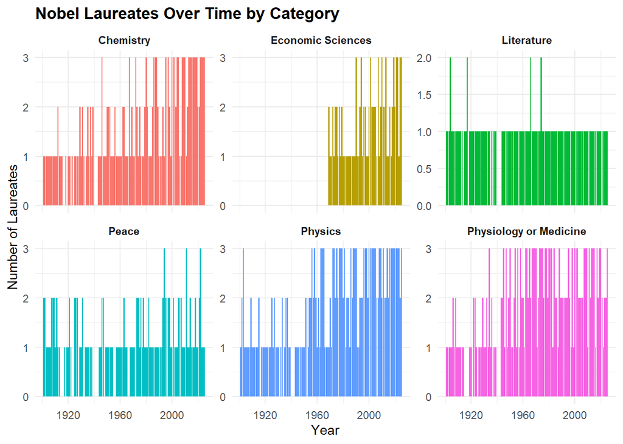

```r
library(ggplot2)

prize_trends <- prize_laureates_clean %>%
  group_by(awardYear, category) %>%
  summarise(n_laureates = n_distinct(id), .groups = "drop")

ggplot(prize_trends, aes(x = awardYear, y = n_laureates, fill = category)) +
  geom_col(show.legend = FALSE) +
  facet_wrap(~category, scales = "free_y") +
  labs(
    title = "Nobel Laureates Over Time by Category",
    x = "Year",
    y = "Number of Laureates"
  ) +
  theme_minimal() +
  theme(
    plot.title = element_text(face = "bold"),
    strip.text = element_text(face = "bold")
  )
```

## Research Question 2: What is the distribution of age at the time of receiving a Nobel Prize across different categories?

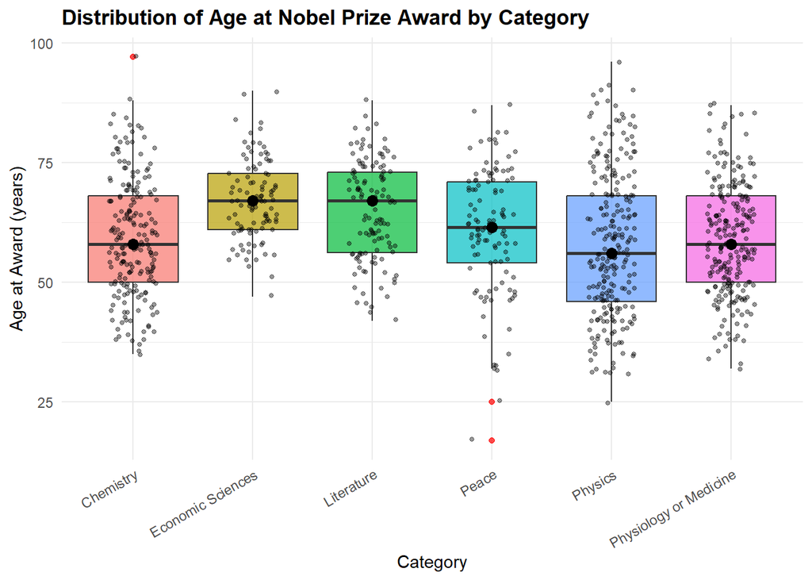

```r
library(tidyverse)

laureates_age <- laureates_full %>%
  mutate(
    birth_year = as.numeric(birth_year),
    awardYear = as.numeric(awardYear),
    age = awardYear - birth_year
  ) %>%
  filter(!is.na(age), age > 0, age < 120)

ggplot(laureates_age, aes(x = category, y = age, fill = category)) +
  geom_boxplot(alpha = 0.7, outlier.color = "red") +
  geom_jitter(width = 0.2, alpha = 0.4, size = 1) +
  stat_summary(fun = median, geom = "point", size = 3, color = "black") +
  labs(
    title = "Distribution of Age at Nobel Prize Award by Category",
    x = "Category",
    y = "Age at Award (years)"
  ) +
  theme_minimal() +
  theme(
    legend.position = "none",
    axis.text.x = element_text(angle = 30, hjust = 1),
    plot.title = element_text(face = "bold")
  )
```

## Research Question 3: Which countries have produced the most Nobel laureates, and how does this compare between birth country and affiliation country?

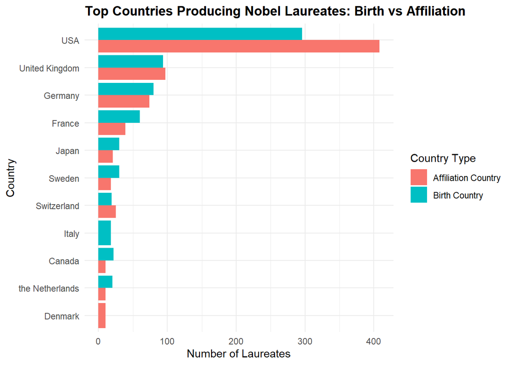

```r
library(tidyverse)

birth_country <- laureates_full %>%
  filter(!is.na(birth_country)) %>%
  group_by(birth_country) %>%
  summarise(n_birth = n_distinct(id), .groups = "drop") %>%
  arrange(desc(n_birth)) %>%
  slice_head(n = 10)

affiliation_country <- laureates_full %>%
  filter(!is.na(affiliation_country)) %>%
  separate_rows(affiliation_country, sep = ",\\s*") %>%
  group_by(affiliation_country) %>%
  summarise(n_affiliation = n_distinct(id), .groups = "drop") %>%
  arrange(desc(n_affiliation)) %>%
  slice_head(n = 10)

birth_country2 <- birth_country %>%
  rename(country = birth_country, count = n_birth) %>%
  mutate(type = "Birth Country")

affiliation_country2 <- affiliation_country %>%
  rename(country = affiliation_country, count = n_affiliation) %>%
  mutate(type = "Affiliation Country")

country_compare <- bind_rows(birth_country2, affiliation_country2)

ggplot(country_compare, aes(x = reorder(country, count), y = count, fill = type)) +
  geom_col(position = "dodge") +
  coord_flip() +
  labs(
    title = "Top Countries Producing Nobel Laureates: Birth vs Affiliation",
    x = "Country",
    y = "Number of Laureates",
    fill = "Country Type"
  ) +
  theme_minimal() +
  theme(
    plot.title = element_text(face = "bold")
  )
```

### Research Question 4: Which Nobel laureates have won prizes in multiple categories?

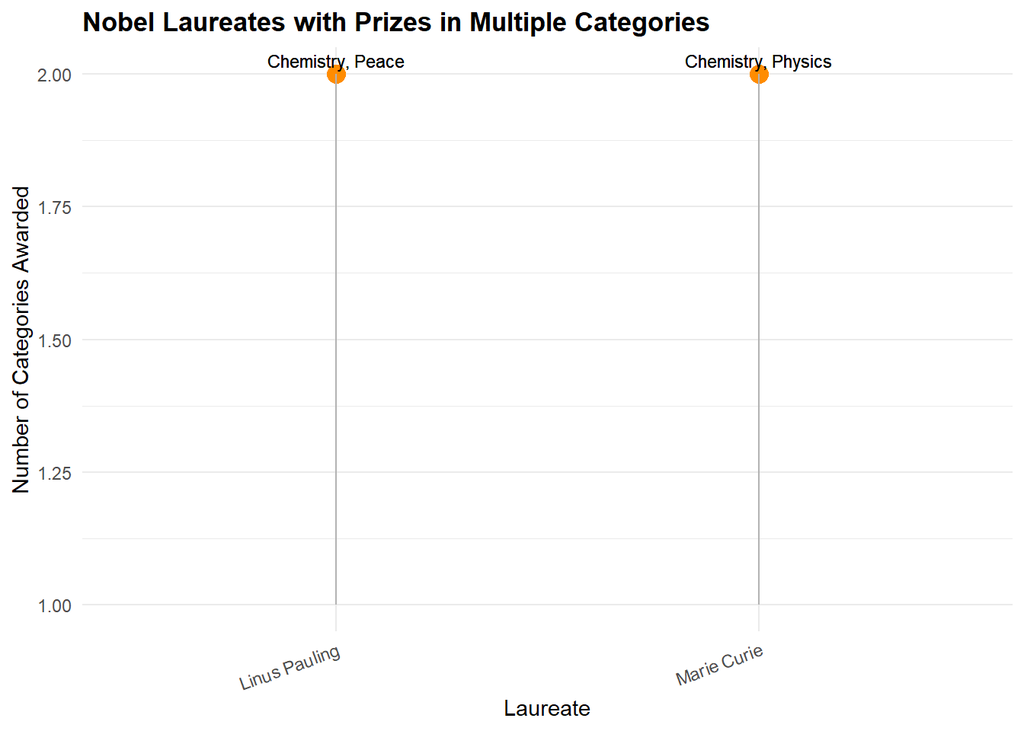

```r
library(tidyverse)

multi_category_laureates <- prize_laureates_clean %>%
  group_by(id) %>%
  summarise(
    n_categories = n_distinct(category),
    categories = paste(sort(unique(category)), collapse = ", "),
    n_prizes = n(),
    .groups = "drop"
  ) %>%
  filter(n_categories > 1)

multi_category_named <- multi_category_laureates %>%
  left_join(
    laureates_clean %>% select(id, fullName),
    by = "id"
  )

ggplot(multi_category_named,
       aes(x = fullName, y = n_categories)) +
  geom_point(size = 4, color = "darkorange") +
  geom_segment(aes(x = fullName, xend = fullName,
                   y = 1, yend = n_categories),
               color = "gray70") +
  geom_text(
    aes(label = categories),
    vjust = -0.5,
    size = 3
  ) +
  labs(
    title = "Nobel Laureates with Prizes in Multiple Categories",
    x = "Laureate",
    y = "Number of Categories Awarded"
  ) +
  theme_minimal() +
  theme(
    axis.text.x = element_text(angle = 20, hjust = 1),
    plot.title = element_text(face = "bold")
  )
```

# Conclusion

This analysis used Nobel Prize API data to explore patterns in laureates’ demographics, award distribution, and geographic mobility. The results show clear temporal trends in prize distribution, meaningful variation in age across categories, and a strong difference between birth country and affiliation country, highlighting global mobility of researchers toward major research hubs. Finally, the analysis confirms that Nobel laureates receiving awards in multiple categories are extremely rare, emphasizing the highly specialized nature of Nobel Prize recognition.

# References

1. OpenAI. (2026). ChatGPT (GPT-5.3) responses on Nobel Prize JSON data analysis, data cleaning, visualization, and R programming support [Large language model]. https://chat.openai.com/